# Practical Machine Learning Assignment

Sreekumar Parameswaran Pillai

October 23, 2015

Objective:

Predict the manner in which they did the exercise that is the “classe” variable in the training set.

Methodology:

Any other variables could be used to predict this. Create a report describing how the model was build, details of cross validation, the expected out of sample error and reasons for any specific choices. The Prediction model should be used to predict 20 different test cases.

Setting the seed value as instructed in the assignment; for reproducability:

```r
set.seed(12345)

rmna.strings <- c("NA","#DIV/0!","")

training <- read.csv("pml-training.csv", na.strings=rmna.strings)
testing <- read.csv("pml-training.csv", na.strings=rmna.strings)
```

Separating the dataset into training and test sets using the recommended ratio: 60:40

```r
inTrain <- createDataPartition(training$classe, p=0.6, list=FALSE)
pmlTraining <- training[inTrain, ]
pmlTesting <- training[-inTrain, ]
dim(pmlTraining)
```

```
## [1] 11776   160
```

```r
dim(pmlTesting)
```

```
## [1] 7846  160
```

Cleaning the input data

Removing NearZeroVariance variables from the input:

```r
nzv <- nearZeroVar(pmlTraining, saveMetrics=TRUE)
myTraining <- pmlTraining[,nzv$nzv==FALSE]

myTesting <- pmlTesting[,nzv$nzv==FALSE]
```

Removing the first few columns column:

```r
myTraining <- pmlTraining[ , 7:160]
myTesting <- pmlTesting[ , 7:160]
```

```r
trainingV3 <- myTraining
for(i in 1:length(myTraining)) {
    if( sum( is.na( myTraining[, i] ) ) /nrow(myTraining) >= .7) {
        for(j in 1:length(trainingV3)) {
            if( length( grep(names(myTraining[i]), names(trainingV3)[j]) ) == 1)  {
                trainingV3 <- trainingV3[ , -j]
            }
        }
    }
}

# Set back to the original variable name
myTraining <- trainingV3
rm(trainingV3)
```

```r
trainCols <- colnames(myTraining)
testCols <- colnames(myTraining[, -54])  # remove the classe column
myTesting <- myTesting[trainCols]         # ensure column are same across train and test datasets
myTesting <- testing[testCols]

dim(myTesting)
```

```
## [1] 19622    53
```

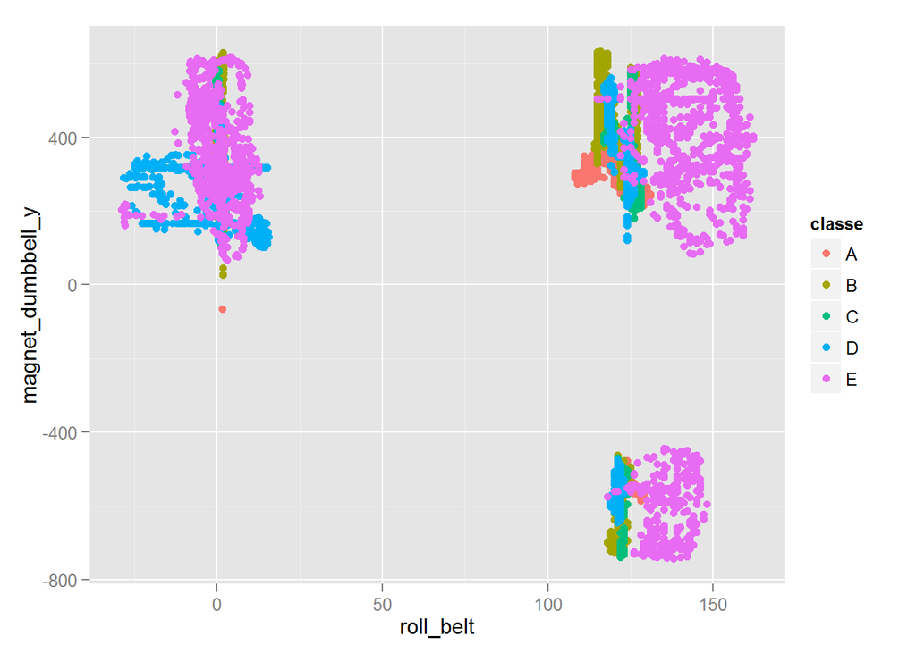

```r
qplot(roll_belt, magnet_dumbbell_y, colour=classe, data=myTraining)
```